# CMDA 3654: Lecture 02

# Basic Numerical Summaries

Make sure that the blood brain dataset is loaded into R before proceeding.

```r
# We learned how to read in data from a .csv file in the previous portion of the lecture. Do the following.
brain <- read.csv(file = "data/bloodbrain.csv", header = T)
```

Most of the basic numerical summaries have obvious names.  If we want to get the mean, sd (standard deviation), and more for variables we can use the same basic pattern.

```r
# The mean of the Liver variable observations from the brain data.frame
mean( brain$Liver )
```

```
[1] 668776.4
```

```r
# The standard deviation of the Liver variable observations from the brain data.frame
sd( brain$Liver )
```

```
[1] 686992.8
```

```r
# There are short-cut functions that do a lot of the basic work for us too such as summary() which provides 5-number summaries
#  (plus the mean) for numerical observations and frequency tables for categorical observations.
summary(brain)
```

```
     Brain            Liver              Time        Treatment      Days           Sex         Weight           Loss            Tumor
 Min.   :  1334   Min.   :    928   Min.   : 0.500   BD:17     Min.   : 9.00   Female:26   Min.   :184.0   Min.   :-4.900   Min.   : 25.0
 1st Qu.: 19281   1st Qu.:  16210   1st Qu.: 1.125   NS:17     1st Qu.:10.00   Male  : 8   1st Qu.:225.2   1st Qu.: 1.200   1st Qu.:136.2
 Median : 32572   Median : 643965   Median : 3.000             Median :10.00               Median :239.5   Median : 3.950   Median :166.0
 Mean   : 39965   Mean   : 668776   Mean   :23.515             Mean   :10.03               Mean   :241.6   Mean   : 3.638   Mean   :182.9
 3rd Qu.: 50654   3rd Qu.:1318557   3rd Qu.:24.000             3rd Qu.:10.00               3rd Qu.:259.0   3rd Qu.: 5.975   3rd Qu.:223.2
 Max.   :123730   Max.   :1790863   Max.   :72.000             Max.   :11.00               Max.   :298.0   Max.   :12.800   Max.   :484.0
```

Don't forget that not all variables are numerical, we have different types of summaries for categorical data.

```r
# We see that the Sex observation is a categorical variable.
brain$Sex
```

```
 [1] Female Female Female Female Female Female Female Female Female Female Female Female Female Female Female Female
[17] Female Female Female Male   Male   Female Female Male   Male   Female Female Female Male   Male   Male   Female
[33] Male   Female
Levels: Female Male
```

```r
# We can make a table of counts (aka, absolute frequencies) with a number of functions, the easiest is table()
table(brain$Sex)
```

```
Female   Male
    26      8
```

```r
# We can make a relative frequency table a number of ways too.
table(brain$Sex)/length(brain$Sex)
```

```
   Female      Male
0.7647059 0.2352941
```

```r
# Or equivalently
prop.table( table(brain$Sex) )
```

```
   Female      Male
0.7647059 0.2352941
```

# Practice Using Numerical Summaries and Logical Subsetting

Try out the following for yourself and read the comments for explanations.

```r
# How can I get the mean of the tumors when the treatment is BD?

# Think about this in steps.

# First, I want just want the Treatments that correspond to the BD treatment
brain$Treatment == "BD"
```

```
 [1]  TRUE  TRUE  TRUE  TRUE  TRUE FALSE FALSE FALSE FALSE  TRUE  TRUE  TRUE  TRUE FALSE FALSE FALSE FALSE FALSE  TRUE
[20]  TRUE  TRUE  TRUE FALSE FALSE FALSE FALSE  TRUE  TRUE  TRUE  TRUE FALSE FALSE FALSE FALSE
```

```r
# If I use the above logical statement as an index, then I can can get the Tumor measurements for
#  rats who were given the BD treatment
# Note we don't have to use which() every time, the TRUEs are the only locations used.
brain$Tumor[ brain$Treatment == "BD" ]
```

```
 [1] 221 246  61 168 164  73  25 133 203 155 190 101 214  39 153 164 364
```

```r
# Now we can take the mean of the Tumor measurements for rats who were given the BD treatment.
mean( brain$Tumor[ brain$Treatment == "BD" ] )
```

```
[1] 157.2941
```

```r
# The last line gives the answer we want and you'll eventually memorize the pattern
```

# Advanced, But Very Useful: The apply() Family in R

* There are other useful functions either in Base R or in library packages that we can use that might be more efficient.

* The `apply()` family is used for quick aggregation and numerical summaries.  Let's just focus on the `tapply()` function for now. You can read more these functions here: [r-apply-functions: https://www.guru99.com/r-apply-sapply-tapply.html](https://www.guru99.com/r-apply-sapply-tapply.html)

Usage:  `tapply( numerical_variable,  categorical_variable,  function_name )`

```r
# Find the means of the Tumor measurements broken down by the different Treatments
tapply( brain$Tumor, brain$Treatment, mean)
```

```
      BD       NS
157.2941 208.5294
```

```r
# Find the standard deviations of the Tumor measurements broken down by the different Treatments
tapply( brain$Tumor, brain$Treatment, sd)
```

```
       BD        NS
 83.99759 116.68393
```

```r
# Find the five-number summary for the Tumor measurements broken down by the different Treatments
tapply( brain$Tumor, brain$Treatment, quantile)
```

```
$BD
  0%  25%  50%  75% 100%
  25  101  164  203  364

$NS
  0%  25%  50%  75% 100%
  27  151  191  264  484
```

# More about Library Packages

* There are many more statistical methods than what you learned about in your first couple of Statistics courses.

* Many of these methods are built into Base R, however there are many library packages that contain additional functions and datasets that we can download and make use of.

* Often times, the new functions are written to do specific tasks in either different and/or more efficient ways.

Let's practice.

Our goal is to install `psych` library package.

* I will demonstrate how to use some point-and-click method to do this for you in a short video clip.

- This generally involves you going to the Packages tab in the bottom right quadrant and clicking "Install" and it will open a dialog box where you can type the name of the package you wish to install.

- In general, I advise you to use the point-and-click method for installation of packages, especially if it's your first time installing a package.  Go ahead and accept the defaults if it asks you questions.

* Alternatively, we can install packages using a function like the one you see below but you never really need to.

The following is a way to install the `psych` library using the Console command line.  You only need to do this once.

```r
install.packages("psych")
```

* Once installed, to enable a library package you can use the point-and-click method or type the Console command line.

```r
library("psych")
```

Make sure that you have installed and enabled the `psych` library.

The point-and-click method requires clicking the Packages Tab and checking the selection box next to `psych`.

```r
# The command line in this case is generally preferred though.
# You generally only need to do this once after R has been opened.
library("psych")  # or library(psych) works too.
```

We can learn about a library package by looking at the help.  This generally lists some information about who wrote the library, and what functions and datasets are contained within.

```r
? psych
```

The `describe()` function is a function that we obtained by downloading and enabling the `psych` library.

```r
# Provides a lot of different times of numerical summaries
describe(brain)
```

```
           vars  n      mean        sd    median   trimmed       mad    min       max     range  skew kurtosis        se
Brain         1 34  39965.29  30326.11  32572.50  36877.39  25373.96 1334.0  123730.0  122396.0  0.93     0.13   5200.88
Liver         2 34 668776.41 686992.77 643965.00 626197.96 939822.36  928.0 1790863.0 1789935.0  0.33    -1.60 117818.29
Time          3 34     23.51     28.80      3.00     20.79      3.71    0.5      72.0      71.5  0.89    -0.93      4.94
Treatment*    4 34      1.50      0.51      1.50      1.50      0.74    1.0       2.0       1.0  0.00    -2.06      0.09
Days          5 34     10.03      0.46     10.00     10.04      0.00    9.0      11.0       2.0  0.12     1.56      0.08
Sex*          6 34      1.24      0.43      1.00      1.18      0.00    1.0       2.0       1.0  1.19    -0.59      0.07
Weight        7 34    241.65     27.49    239.50    241.39     23.72  184.0     298.0     114.0 -0.01    -0.49      4.72
Loss          8 34      3.64      4.24      3.95      3.72      3.85   -4.9      12.8      17.7 -0.12    -0.26      0.73
Tumor         9 34    182.91    103.43    166.00    175.18     83.77   25.0     484.0     459.0  0.71     0.57     17.74
```

We will download other libraries throughout the course.

# Numerical Summaries on Subsets of Data Frames

```r
# Recall the full brain data set, you can look at it on your own.
View(brain)  # or just type print(brain)
```

```r
# Return only the observations where the treatment was BD
# We can save this into a new data frame if we wish
brain_BD_only <- subset(brain, Treatment == "BD")
brain_BD_only
```

```
    Brain   Liver Time Treatment Days    Sex Weight Loss Tumor
1   41081 1456164  0.5        BD   10 Female    239  5.9   221
2   44286 1602171  0.5        BD   10 Female    225  4.0   246
3  102926 1601936  0.5        BD   10 Female    224 -4.9    61
4   25927 1776411  0.5        BD   10 Female    184  9.8   168
5   42643 1351184  0.5        BD   10 Female    250  6.0   164
10  77961 1060057  3.0        BD   10 Female    267  2.6    73
11  73178  715581  3.0        BD   10 Female    263  1.1    25
12  76167  620145  3.0        BD   10 Female    228  0.0   133
13 123730 1068423  3.0        BD    9 Female    261  3.4   203
19  84616   48815 24.0        BD   10 Female    254  3.9   155
20  55153   16885 24.0        BD   10   Male    256 -4.7   190
21  48829   22395 24.0        BD   10   Male    247 -2.8   101
22  89454   83504 24.0        BD   11 Female    198  4.2   214
27  35395    4142 72.0        BD   11 Female    251  4.1    39
28  18270    2364 72.0        BD   10 Female    223  4.0   153
29   5625    1979 72.0        BD   10   Male    298 12.8   164
30   7497    1659 72.0        BD   10   Male    260  7.3   364
```

```r
# Return only the observations where the treatment was NS
# We can save this into a new data frame if we wish
brain_NS_only <- subset(brain, Treatment == "NS")
brain_NS_only
```

```
   Brain   Liver Time Treatment Days    Sex Weight Loss Tumor
6  31342 1790863  0.5        NS   10 Female    196  7.7   260
7  22815 1633386  0.5        NS   10 Female    200  0.5    27
8  16629 1618757  0.5        NS   10 Female    273  4.0   308
9  22315 1567602  0.5        NS   10 Female    216  2.8    93
14 25569  721436  3.0        NS    9 Female    253  5.9   159
15 33803 1019352  3.0        NS   10 Female    234  0.1   264
16 24512  667785  3.0        NS   10 Female    238  0.8    34
17 50545  961097  3.0        NS    9 Female    230  7.0   146
18 50690 1220677  3.0        NS   10 Female    207  1.5   212
23 37928   20323 24.0        NS   10 Female    237  2.5   224
24 12816   15985 24.0        NS   10   Male    293  3.1   151
25 23734   25895 24.0        NS   10   Male    288  9.7   285
26 31097   33224 24.0        NS   11 Female    236  5.9   380
31  6250     928 72.0        NS   10   Male    272 11.0   484
32 11519    2423 72.0        NS   11 Female    226  2.2   168
33  3184    1608 72.0        NS   10   Male    249 -4.4   191
34  1334    3242 72.0        NS   10 Female    240  6.7   159
```

* We can use logical operators to subset our data frames into very specific cases.

```r
# Subset the BD treatments AND just the Females
subset(brain, Treatment == "BD" & Sex == "Female")
```

```
    Brain   Liver Time Treatment Days    Sex Weight Loss Tumor
1   41081 1456164  0.5        BD   10 Female    239  5.9   221
2   44286 1602171  0.5        BD   10 Female    225  4.0   246
3  102926 1601936  0.5        BD   10 Female    224 -4.9    61
4   25927 1776411  0.5        BD   10 Female    184  9.8   168
5   42643 1351184  0.5        BD   10 Female    250  6.0   164
10  77961 1060057  3.0        BD   10 Female    267  2.6    73
11  73178  715581  3.0        BD   10 Female    263  1.1    25
12  76167  620145  3.0        BD   10 Female    228  0.0   133
13 123730 1068423  3.0        BD    9 Female    261  3.4   203
19  84616   48815 24.0        BD   10 Female    254  3.9   155
22  89454   83504 24.0        BD   11 Female    198  4.2   214
27  35395    4142 72.0        BD   11 Female    251  4.1    39
28  18270    2364 72.0        BD   10 Female    223  4.0   153
```

```r
# Subset the BD treatments AND just the Males
subset(brain, Treatment == "BD" & Sex == "Male")
```

```
   Brain Liver Time Treatment Days  Sex Weight Loss Tumor
20 55153 16885   24        BD   10 Male    256 -4.7   190
21 48829 22395   24        BD   10 Male    247 -2.8   101
29  5625  1979   72        BD   10 Male    298 12.8   164
30  7497  1659   72        BD   10 Male    260  7.3   364
```

```r
# This returns only the Tumor variable when the treatment is BD
# we can save this into a new data frame if we wish
tumor_weight_BD_df <- subset(brain,
                             Treatment == "BD",
                             select = "Tumor")
tumor_weight_BD_df
```

```
   Tumor
1    221
2    246
3     61
4    168
5    164
10    73
11    25
12   133
13   203
19   155
20   190
21   101
22   214
27    39
28   153
29   164
30   364
```

```r
# Let's do the same thing but only get the NS treatments
# This returns only the Tumor variable when the treatment is NS
# we can save this into a new data frame if we wish
tumor_weight_NS_df <- subset(brain,
                             Treatment == "NS",
                             select = "Tumor")
```

* Sometimes we don't want to return an entire data frame, and instead just the observations for various situations.

```r
# Returns tumor weights from the brain dataset
#  where the treatment is BD.
brain$Tumor[ brain$Treatment == "BD" ]
```

```
 [1] 221 246  61 168 164  73  25 133 203 155 190 101 214  39 153 164
[17] 364
```

```r
# Returns tumor weights from the brain dataset
#  where the treatment is NS.
brain$Tumor[ brain$Treatment == "NS" ]
```

```
 [1] 260  27 308  93 159 264  34 146 212 224 151 285 380 484 168 191
[17] 159
```

```r
# The mean tumor weights for all rats on the BD Treatment
tumor_mean_BD <- mean( brain$Tumor[ brain$Treatment == "BD" ] )
tumor_mean_BD
```

```
[1] 157.2941
```

```r
# The mean tumor weights for all rats on the NS Treatment
tumor_mean_NS <- mean( brain$Tumor[ brain$Treatment == "NS" ] )
tumor_mean_NS
```

```
[1] 208.5294
```

```r
# The mean tumor weights for Female rats on the BD Treatment
tumor_mean_BD_F <- mean( brain$Tumor[ brain$Treatment == "BD" &
                                        brain$Sex == "Female" ] )
tumor_mean_BD_F
```

```
[1] 142.6923
```

```r
# The mean tumor weights for Female rats on the NS Treatment
tumor_mean_NS_F <- mean( brain$Tumor[ brain$Treatment == "NS" &
                                        brain$Sex == "Female" ] )
tumor_mean_NS_F
```

```
[1] 187.2308
```

&nbsp;

* By now you should see that I am carefully storing my answer in what I think are very good object names.

```r
# On the previous slide, we saw the & can be used as an intersection condition, that is,
#  we want condition 1 & condition 2 to be satisfied.
# Hence, TRUE is both conditions are satisfied, FALSE otherwise.
brain$Treatment == "BD" & brain$Sex == "Female"
```

```
 [1]  TRUE  TRUE  TRUE  TRUE  TRUE FALSE FALSE FALSE FALSE  TRUE  TRUE  TRUE  TRUE FALSE FALSE FALSE FALSE FALSE  TRUE
[20] FALSE FALSE  TRUE FALSE FALSE FALSE FALSE  TRUE  TRUE FALSE FALSE FALSE FALSE FALSE FALSE
```

```r
# We also use a union condition, i.e. we want either condition 1 or condition 2 (or both) to be satisfied.
#  The notation for "or" is the | symbol.
# Hence TRUE if Treatment is BD or Sex is Female or both are true.
#  Otherwise, FALSE (Males with NS treatment)
brain$Treatment == "BD" | brain$Sex == "Female"
```

```
 [1]  TRUE  TRUE  TRUE  TRUE  TRUE  TRUE  TRUE  TRUE  TRUE  TRUE  TRUE  TRUE  TRUE  TRUE  TRUE  TRUE  TRUE  TRUE  TRUE
[20]  TRUE  TRUE  TRUE  TRUE FALSE FALSE  TRUE  TRUE  TRUE  TRUE  TRUE FALSE  TRUE FALSE  TRUE
```

```r
# Consider the Time Variable
brain$Time
```

```
 [1]  0.5  0.5  0.5  0.5  0.5  0.5  0.5  0.5  0.5  3.0  3.0  3.0  3.0  3.0  3.0  3.0  3.0  3.0 24.0 24.0 24.0 24.0 24.0
[24] 24.0 24.0 24.0 72.0 72.0 72.0 72.0 72.0 72.0 72.0 72.0
```

```r
brain$Time <= 0.5 # Times less than or equal to 0.5
```

```
 [1]  TRUE  TRUE  TRUE  TRUE  TRUE  TRUE  TRUE  TRUE  TRUE FALSE FALSE FALSE FALSE FALSE FALSE FALSE FALSE FALSE FALSE
[20] FALSE FALSE FALSE FALSE FALSE FALSE FALSE FALSE FALSE FALSE FALSE FALSE FALSE FALSE FALSE
```

```r
brain$Time > 24 # Times greater than 24
```

```
 [1] FALSE FALSE FALSE FALSE FALSE FALSE FALSE FALSE FALSE FALSE FALSE FALSE FALSE FALSE FALSE FALSE FALSE FALSE FALSE
[20] FALSE FALSE FALSE FALSE FALSE FALSE FALSE  TRUE  TRUE  TRUE  TRUE  TRUE  TRUE  TRUE  TRUE
```

```r
# Both conditions can't be satisfied simultaneously
brain$Time <= 0.5 & brain$Time > 24
```

```
 [1] FALSE FALSE FALSE FALSE FALSE FALSE FALSE FALSE FALSE FALSE FALSE FALSE FALSE FALSE FALSE FALSE FALSE FALSE FALSE
[20] FALSE FALSE FALSE FALSE FALSE FALSE FALSE FALSE FALSE FALSE FALSE FALSE FALSE FALSE FALSE
```

```r
# Condition 1 OR Condition 2 can be true
brain$Time <= 0.5 | brain$Time > 24
```

```
 [1]  TRUE  TRUE  TRUE  TRUE  TRUE  TRUE  TRUE  TRUE  TRUE FALSE FALSE FALSE FALSE FALSE FALSE FALSE FALSE FALSE FALSE
[20] FALSE FALSE FALSE FALSE FALSE FALSE FALSE  TRUE  TRUE  TRUE  TRUE  TRUE  TRUE  TRUE  TRUE
```

&nbsp;

* It takes practice to use logical statements effectively, but it is an absolute requirement for when you want to subset data efficiently.

# Some* Basic Plots Using Base R

*There are simply too many out there, but here are some common ones

# Scatterplots

Let's review plotting with a few examples that highlight some basic techniques that you studied in a Statistics course.

* We already saw a couple of basic examples of scatter plots.

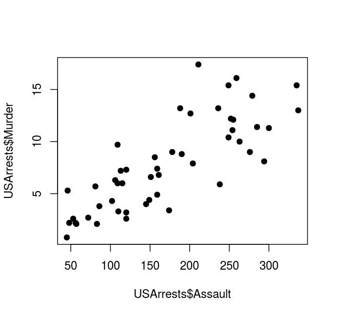

Scatterplot 1

```r
# Usage: plot( x_variable, y_variable).
#    OR: plot( y_variable ~ x_variable )
# Note: the ~ key is next to the 1 key on US keyboards.
# The x variable is called the predictor/explanatory variable,
# The y_variable is called the response variable.

plot( x = USArrests$Assault, y = USArrests$Murder, pch = 19)

# It's understood that x is first, then y
plot( USArrests$Assault, USArrests$Murder, pch = 19)

# Alternatively we can do
plot( USArrests$Murder ~ USArrests$Assault, pch = 19)
# (think y versus x with this technique)
```

&nbsp;

Let's make the plot more fancy by adding labels and a title

* See the R Tutorial for more examples

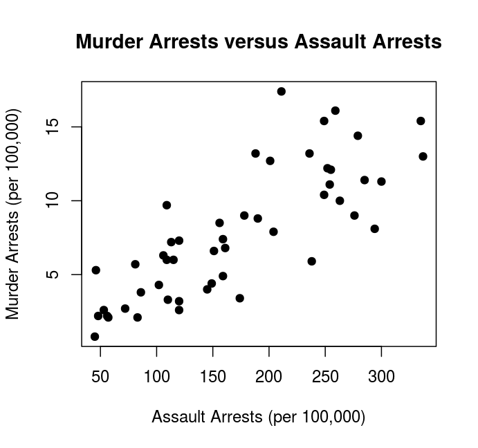

Scatterplot 2

```r
plot(USArrests$Assault, USArrests$Murder,
     pch = 19,
     xlab = "Assault Arrests (per 100,000)",
     ylab = "Murder Arrests (per 100,000)",
     main = "Murder Arrests versus Assault Arrests" )
```

&nbsp;

* We can use our logical statements and store indices for special situations.

```r
# Which of the points above occur in states that have an
#  urban population greater than 80%?
pop_greater_80_index <- which(USArrests$UrbanPop > 80)
pop_greater_80_index
```

```
[1]  5 11 13 21 28 30 32 39
```

```r
# What states have an urban population greater than 80%?
row.names(USArrests)[ pop_greater_80_index ]
```

```
[1] "California"    "Hawaii"        "Illinois"      "Massachusetts"
[5] "Nevada"        "New Jersey"    "New York"      "Rhode Island"
```

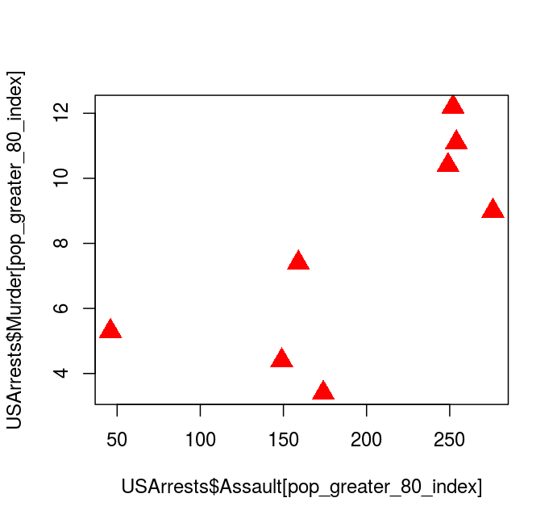

Scatterplot 3

```r
# Now let's plot the Assaults and Murders in states
#  where the urban population is greater than 80%
plot(x = USArrests$Assault[pop_greater_80_index],
y = USArrests$Murder[pop_greater_80_index],
pch = 17,
col = "red",
cex = 2) # Makes the plot character 200% bigger
```

&nbsp;

* If we have an existing plot, we can add additional points to it afterwards.

- We can also add text, lines, and other plotting images too but you'll learn this over time.

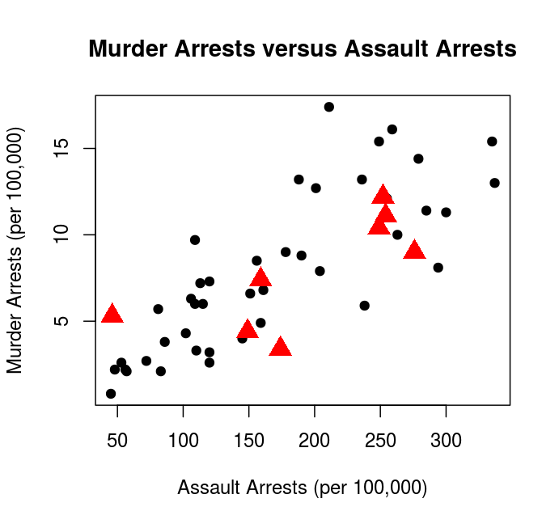

Scatterplot 4

```r
# First plot all of the points
plot(USArrests$Assault, USArrests$Murder,
     pch = 19,
     xlab = "Assault Arrests (per 100,000)",
     ylab = "Murder Arrests (per 100,000)",
     main = "Murder Arrests versus Assault Arrests" )


# Then add additional points to the plot
points(x = USArrests$Assault[pop_greater_80_index],
       y = USArrests$Murder[pop_greater_80_index],
       pch = 17,
       col = "red",
       cex = 2)
```

* Let's add some text in addition to the triangles

```r
# First plot all of the points
plot(USArrests$Assault, USArrests$Murder,
pch = 19,
xlab = "Assault Arrests (per 100,000)",
ylab = "Murder Arrests (per 100,000)",
main = "Murder Arrests versus Assault Arrests" )


# Then add additional points to the plot
points(x = USArrests$Assault[pop_greater_80_index],
y = USArrests$Murder[pop_greater_80_index],
pch = 17,
col = "red",
cex = 2)

# We can add labels
text( USArrests$Assault[pop_greater_80_index],
USArrests$Murder[pop_greater_80_index],
row.names(USArrests)[ pop_greater_80_index ])
```

&nbsp;

Conclusion:  Having a high Urban population does not necessarily mean that you will have high numbers of Murders and Assaults as Hawaii, Massachusetts, and Rhode Island are clear exceptions.

Let's make this plot bigger and use the whole next slide for a better look.

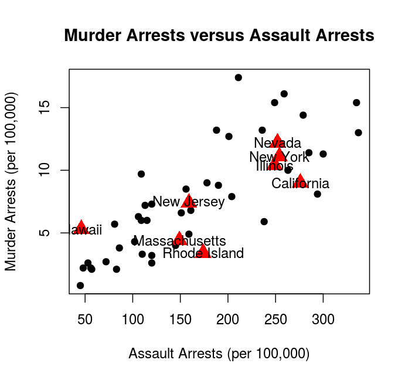

Scatterplot 5

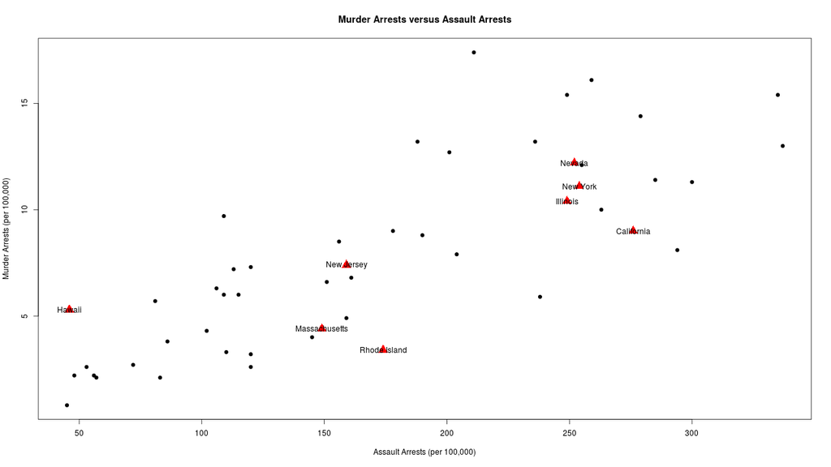

Scatterplot 5 but Bigger

# Histograms

&nbsp;

Histograms are a very important data visualization tool.

* The default histogram uses absolute frequencies.

* R decides automatically how many bins (and bin size) to use.
- All bins are the same width by default.

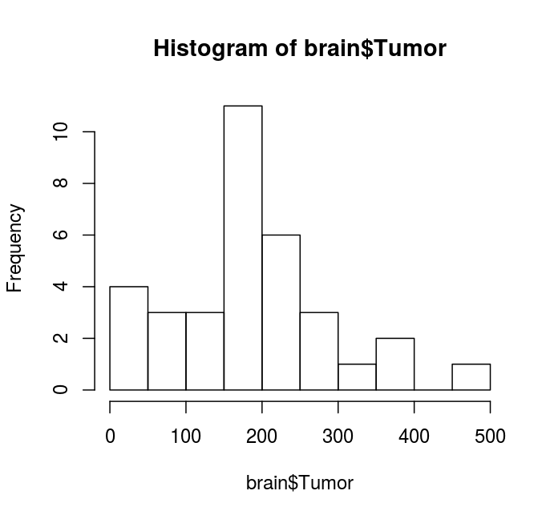

Histogram 1

```r
hist(brain$Tumor)
```

&nbsp;

* We can make a relative frequency histogram in R with a simple option.

* Note that in reality R is making density histograms and not typical relative frequency histograms.

- The difference is that the bar widths have meaning so that the probability is not given by the height, it's given by the area.

```r
hist(brain$Tumor, probability = T)
```

Suggested Reading: Learning how to manipulate the axes and tick locations.

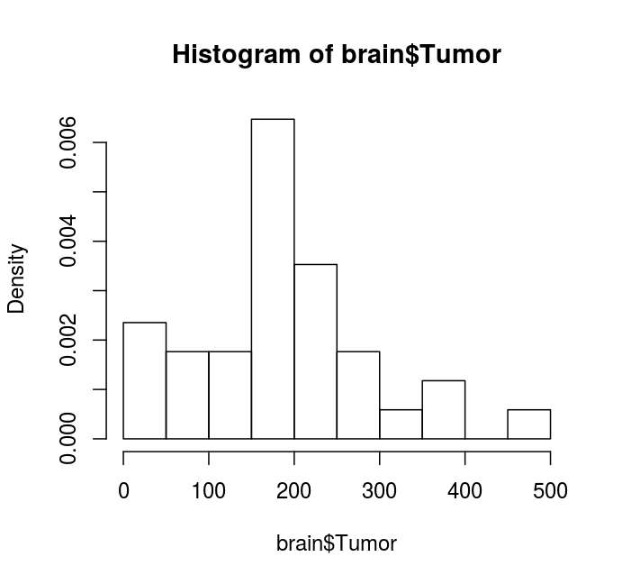

Histogram 2

&nbsp;

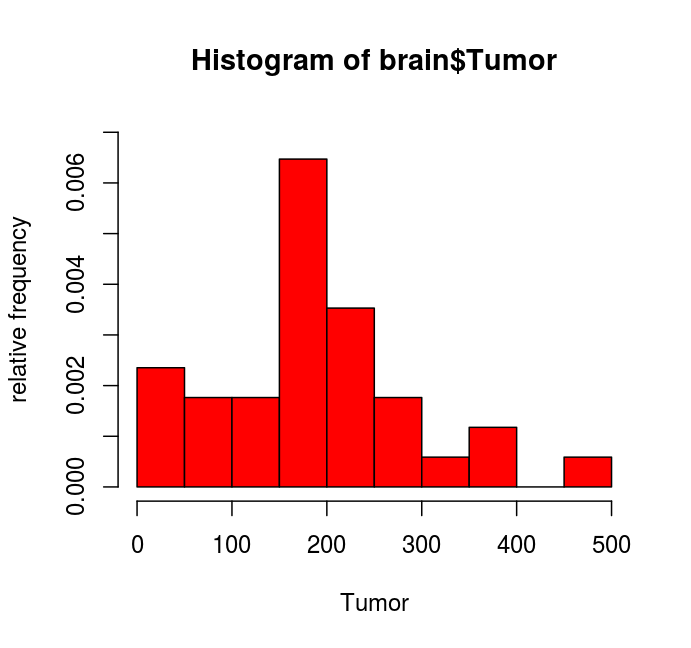

Histogram 3

```r
hist(brain$Tumor,
     probability = T,
     ylim = c(0, 0.007), # This zooms out in the y-direction
     xlab = "Tumor",
     ylab = "relative frequency",
     col = "red")
```

&nbsp;

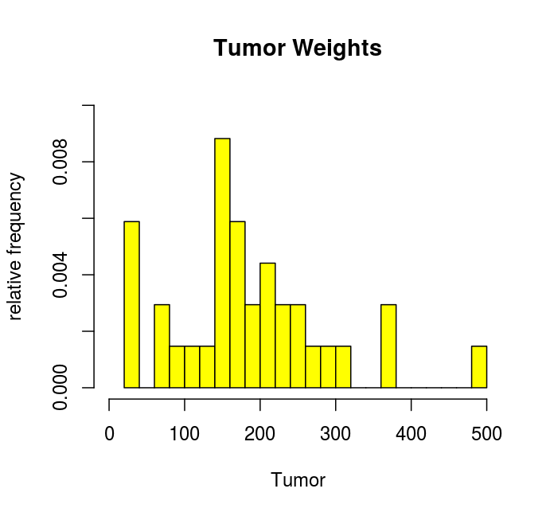

Histogram 4

```r
# We can control the number of bins using different methods,
#  but the easiest is to just ask for the number of breaks.
#  R will do it's best to give us that many breaks.
hist(brain$Tumor,
     probability = T,
     xlim = c(0, 500) ,
     ylim = c(0, 0.010),
     xlab = "Tumor",
     ylab = "relative frequency",
     main = "Tumor Weights",
     breaks = 20, # We want 20 breaks, which means more bins
     col = "yellow")
```

# Boxplots

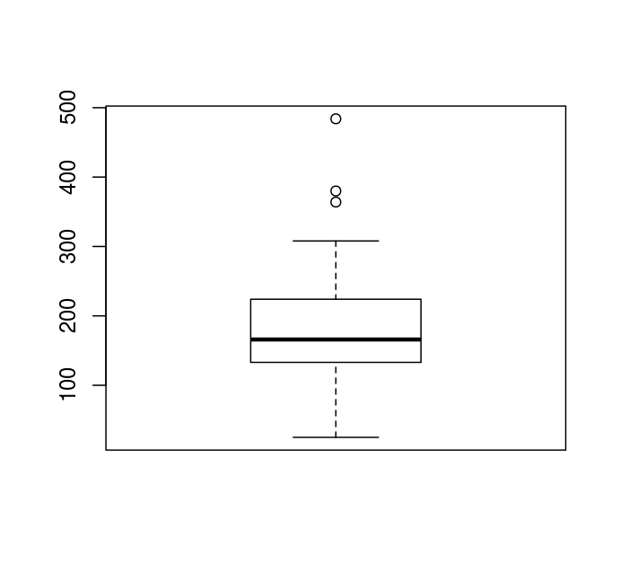

Boxplot 1

```r
# For a single boxplot, simply do the following:
boxplot( brain$Tumor )
```

&nbsp;

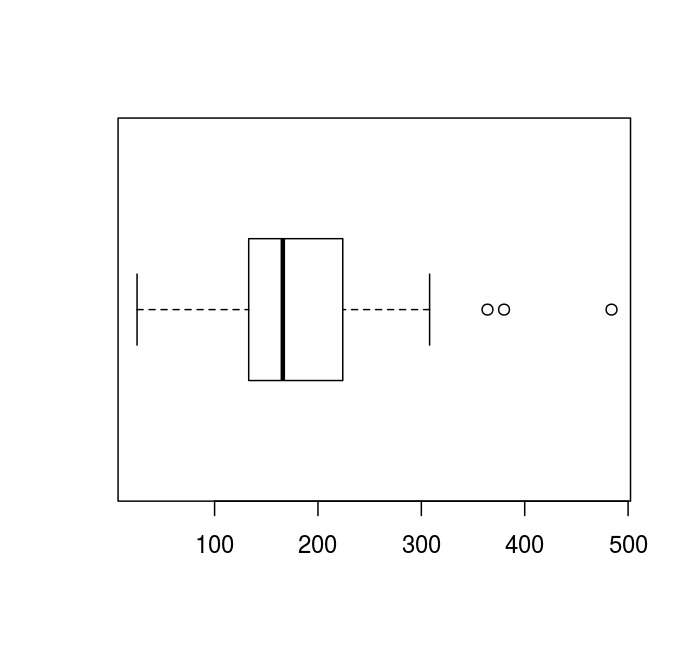

Boxplot 2

```r
# We can change the orientation of the boxplots easily enough

boxplot( brain$Tumor,
         horizontal = T)
```

&nbsp;

* We suspect that Tumor weight might be different between male and female rats.

- We should use side-by-side boxplots to visualize this

The notation we use is one we'll see often through this course.
Usage: `boxplot( response_variable ~ explanatory_variable)`

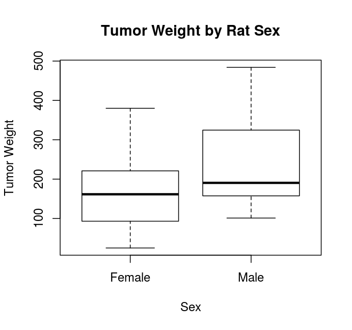

Boxplot 3

```r
boxplot(brain$Tumor ~ brain$Sex,
        xlab = "Sex",
        ylab = "Tumor Weight",
        main = "Tumor Weight by Rat Sex")
```

&nbsp;

[figure not shown]

Boxplot 4

```r
# We can also look at Tumor differences
#  between the different treatments.
boxplot(brain$Tumor ~ brain$Treatment,
        xlab = "Drug Treatment",
        lab = "Tumor Weight",
        main = "Tumor Weight by Treatment")
```

# Barplots

You probably remember barplots well.

* Some things to keep in mind.  Unlike histograms, for barplots...

- The widths of the bars are meaningless

- The distance between the bars are also meaningless.

```r
barplot( table( brain$Sex ) ,
         ylim = c(0, 30),
         col = c("pink" , "blue"),
         main = "Number of Rats of each Sex in the Study" )
```

* In this case, we have 2 categories, so we specified a different color for each.

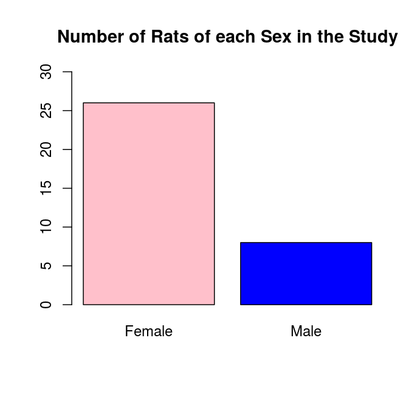

Barplot 1

&nbsp;

* For relative frequencies we just need to do a little more work, again there are many other ways to do this.

```r
barplot( table( brain$Sex ) / sum(table(brain$Sex)) ,
ylim = c(0, 0.8),
col = c("pink","blue"),
main = "Proportion of Rats of each Sex in the Study")
```

Feel free to look at the R Tutorial for more examples.

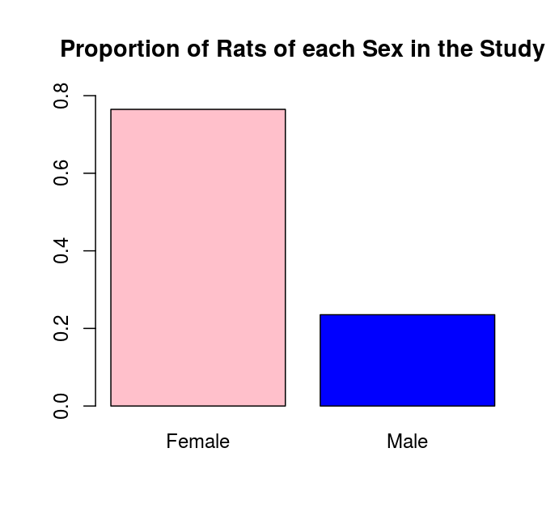

Barplot 2

# Practicum

InsectSprays is a built-in dataset that compares the efficacy of different types of insect sprays.

```r
data(InsectSprays)
```

Answer the following questions using functions your learned in this lecture and interpret if neccessary by typing a comment.

1. What is the structure of this data set?

2. Use the help to describe what the variables represent.

3. Find the mean count regardless of the the spray type

4. Find the 5 number summary for the count regardless of the spray type.
  - Additionally, find the 58th percentile of the count variable using the `quantile()` function. Use `? quantile` if lost.

5. Generate a relative frequency histogram with 10 breaks for the count variable. Label aspects appropriately. Feel free to customize it further if you like.

6. Make a boxplot for all of the count data, are there any outliers?

7. Make side-by-side boxplots where count is the response variable and spray type is the explanatory variable.  Use a different color for each boxplot.

8. Use the `tapply()` function to find the mean and the standard of the counts for the different types of Sprays.
  - Compare this with just using the `mean()` and `sd()` one at a time for each spray type.

9. Use the `subset()` function to return a data frame that consists of only the "C" spray.

10. Use indexing along with logical operators to find the mean count when the "D" spray was used.

**11.** Suppose sprays A and B are actually the same spray.  Ooops!  How can we combine their observations to get the correct mean?

There are many ways that this can be done.  The easiest is to notice that all of the observations are grouped. All the A's occur first in the data set, then the B's, etc.

In practice the observations are usually scrambled (order in which they were collected).  So we should use logical operators to find all of the observations from sprays A and B.

Let's scramble the data so that we are forced to search properly and then obtain our final goal.

```r
# To help you practice this honestly, let's scramble the dataset
set.seed(0)
q <- sample(1:72)
myinsectsprays <- InsectSprays[q, ]
View(myinsectsprays)  # We can see that the rows are scrampbled by looking at the dataframe again.
```

```r
# Now obtain the mean of the count for the combined observations from sprays A and B.
# This is a bit longer than necessary, but might help you if you get stuck.
myindex <- c(which(myinsectsprays$spray == "A"), which(myinsectsprays$spray == "B"))

# Now we can take the mean doing the following:
mean( myinsectsprays$count[ myindex ] )

# A more efficient way is to do the following:
mean( myinsectsprays$count[ myinsectsprays$spray == "A" | myinsectsprays$spray == "B" ]   )
```

Study the above and try to understand what's going on.